# Comparacion Duracion Baterias Siemens 1005

Francisco Gallardo, Celeste Aduviri, Cinthia Ovando, Mauricio Arias

2023-06-19

## Caso de estudio practico - Comparacion de Baterias de autoelevador VARTA 75 Y SIEMENS 1005

Recuperacion de datos via Web.

# DATOS VARTA 75

```r
datos_75 <- c(1 , 19 , 0,
2 , 18 , 0,
3 , 22 , 0,
4 , 25 , 0,
5 , 17 , 0,
6 , 30 , 0,
7 , 29 , 0,
8 , 32 , 0,
9 , 31 , 0,
10, 33 , 0,
11, 38 , 0,
12, 36 , 0,
13, 40 , 1,
14, 40 , 0,
15, 42 , 0,
16, 45 , 0,
17, 47 , 0,
18, 49 , 0,
19, 55 , 0,
20, 58 , 1,
21, 57 , 1,
22, 63 , 1,
23, 65 , 1,
24, 65 , 1,
25, 66 , 1)
Muestra_75 <- matrix(datos_75, ncol = 3, byrow = TRUE)
Muestra_75
```

```
##       [,1] [,2] [,3]
##  [1,]    1   19    0
##  [2,]    2   18    0
##  [3,]    3   22    0
##  [4,]    4   25    0
##  [5,]    5   17    0
##  [6,]    6   30    0
##  [7,]    7   29    0
##  [8,]    8   32    0
##  [9,]    9   31    0
## [10,]   10   33    0
## [11,]   11   38    0
## [12,]   12   36    0
## [13,]   13   40    1
## [14,]   14   40    0
## [15,]   15   42    0
## [16,]   16   45    0
## [17,]   17   47    0
## [18,]   18   49    0
## [19,]   19   55    0
## [20,]   20   58    1
## [21,]   21   57    1
## [22,]   22   63    1
## [23,]   23   65    1
## [24,]   24   65    1
## [25,]   25   66    1
```

# DATOS SIEMENS 1005

```r
datos_1005 <- c(1 , 19 , 0,
2 , 18 , 0,
3 , 22 , 0,
4 , 25 , 0,
5 , 17 , 0,
6 , 30 , 0,
7 , 29 , 0,
8 , 32 , 0,
9 , 31 , 0,
10, 33 , 0,
11, 38 , 0,
12, 36 , 0,
13, 40 , 1,
14, 40 , 0,
15, 42 , 0,
16, 45 , 0,
17, 47 , 0,
18, 49 , 0,
19, 55 , 0,
20, 58 , 1,
21, 57 , 1,
22, 63 , 1,
23, 65 , 1,
24, 65 , 1,
25, 66 , 1,
26, 69 , 1,
27, 70 , 1,
28, 71 , 1,
29, 75 , 1,
30, 86 , 1,
31, 79 , 1,
32, 88 , 1,
33, 89 , 0,
34, 92 , 1,
35, 84, 1)
Muestra_1005 <- matrix(datos_1005, ncol = 3, byrow = TRUE)
Muestra_1005
```

```
##       [,1] [,2] [,3]
##  [1,]    1   19    0
##  [2,]    2   18    0
##  [3,]    3   22    0
##  [4,]    4   25    0
##  [5,]    5   17    0
##  [6,]    6   30    0
##  [7,]    7   29    0
##  [8,]    8   32    0
##  [9,]    9   31    0
## [10,]   10   33    0
## [11,]   11   38    0
## [12,]   12   36    0
## [13,]   13   40    1
## [14,]   14   40    0
```

[output cut: 21 more lines]

Para encontrar la posicion del valor maximo which.max(Muestra_1005[1:35], y el numero de columna). Con el resultado, usar Muestra_1005[Resultado, columna]

```r
which.max(Muestra_75[1:25,2])
```

```
## [1] 25
```

```r
Muestra_1005[25,2]
```

```
## [1] 66
```

```r
which.max(Muestra_1005[1:35,2])
```

```
## [1] 34
```

```r
Muestra_1005[34,2]
```

```
## [1] 92
```

## Graficos

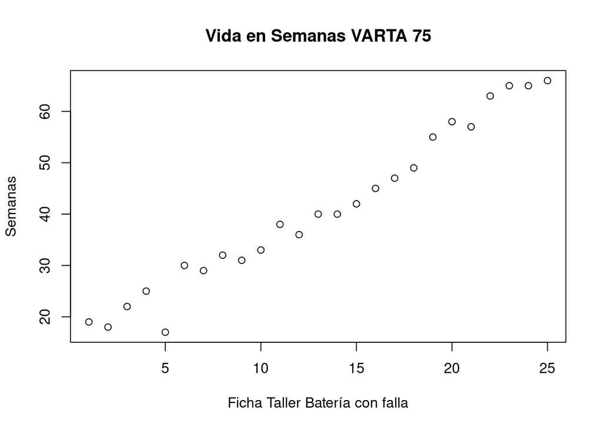

```r
plot (Muestra_75[ ,2],
main= "Vida en Semanas VARTA 75",xlab="Ficha Taller Batería con falla", ylab= "Semanas")
```

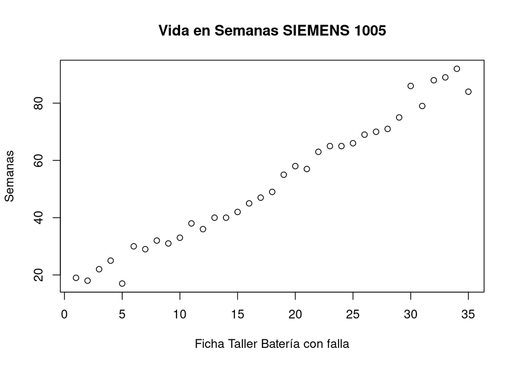

```r
plot (Muestra_1005[ ,2],
main= "Vida en Semanas SIEMENS 1005",xlab="Ficha Taller Batería con falla", ylab= "Semanas")
```

# Promedio de vida

```r
vida_media_muestra <- mean(Muestra_75[,2])
vida_media_muestra
```

```
## [1] 40.88
```

```r
vida_media_muestra <- mean(Muestra_1005[,2])
vida_media_muestra
```

```
## [1] 52.14286
```

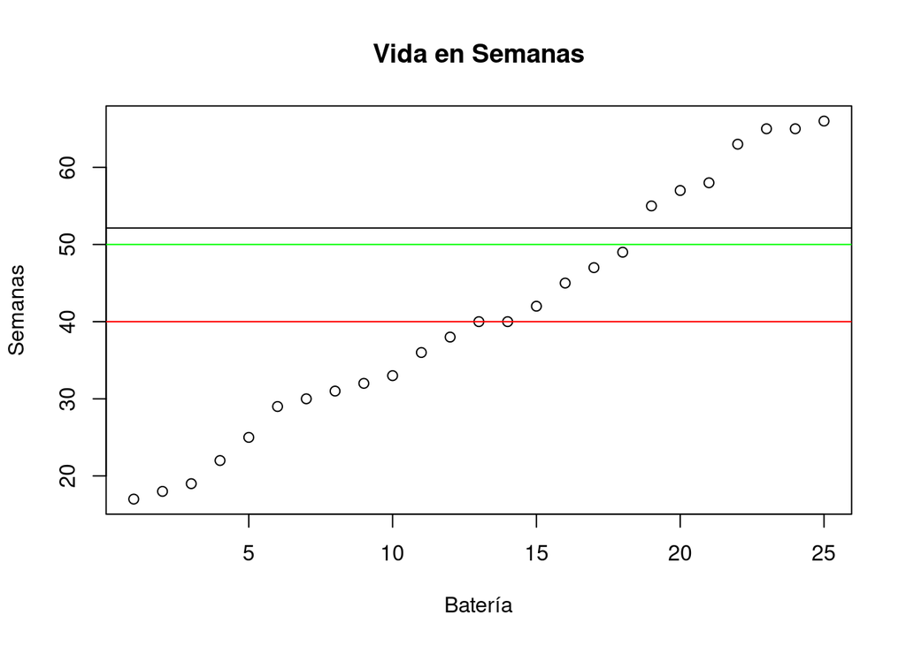

```r
plot (sort(Muestra_75[ ,2]), main= "Vida en Semanas",xlab="Batería", ylab= "Semanas")
abline(h=vida_media_muestra)
abline(h=40,col="red")
abline(h=50,col="green")
```

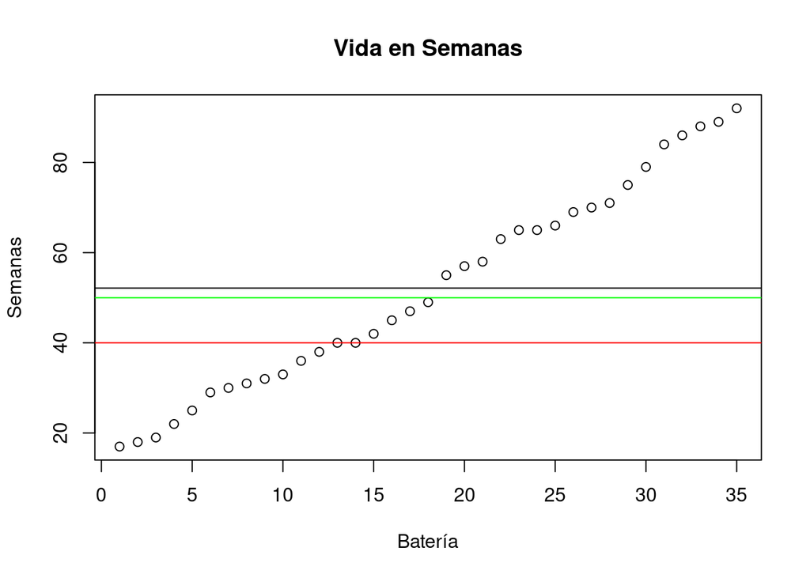

```r
plot (sort(Muestra_1005[ ,2]), main= "Vida en Semanas",xlab="Batería", ylab= "Semanas")
abline(h=vida_media_muestra)
abline(h=40,col="red")
abline(h=50,col="green")
```

La línea roja muestra la duración mínima por contrato garantizada por el fabricante. La línea verde indica la duración máxima de la carga e indica si el producto conserva el electrolito original. Se puede extender la duración de la carga con otro electrolíto no original, pero no tendrá garantía del fabricante en caso de fallas.

# Muestra de Historial de Carga

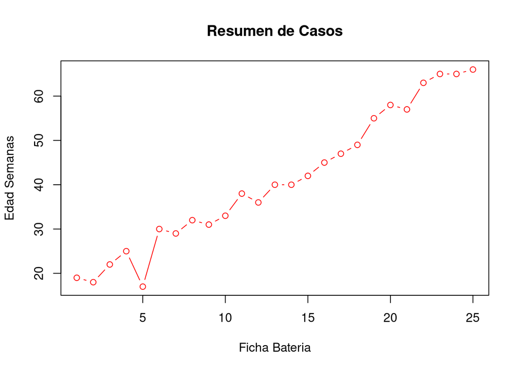

```r
plot(Muestra_75[ , 1:2],main = "Resumen de Casos",xlab = "Ficha Bateria",ylab="Edad Semanas", type="b", col="RED")
```

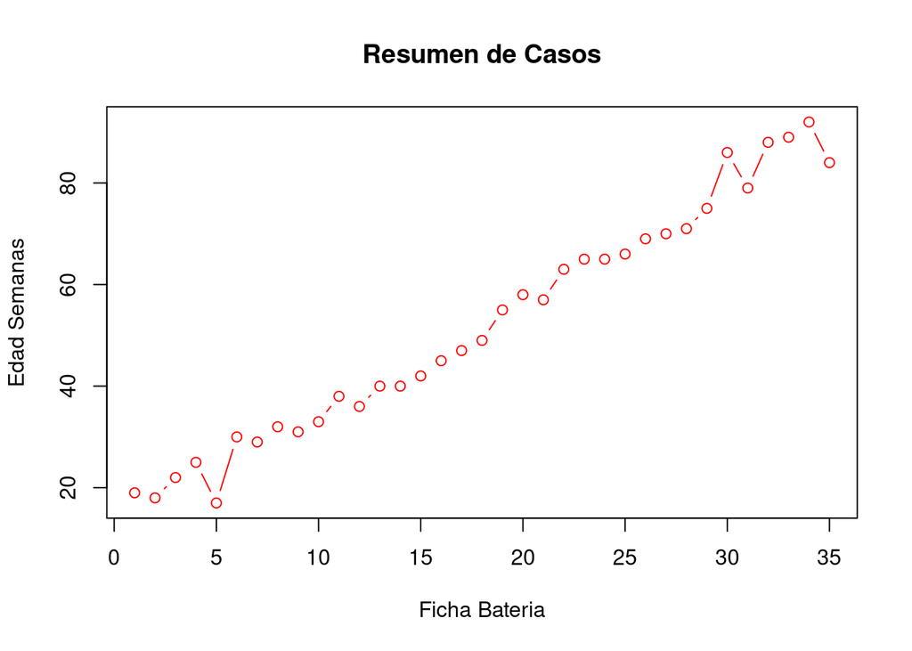

```r
plot(Muestra_1005[ , 1:2],main = "Resumen de Casos",xlab = "Ficha Bateria",ylab="Edad Semanas", type="b", col="RED")
```

# Histogramas de Edades

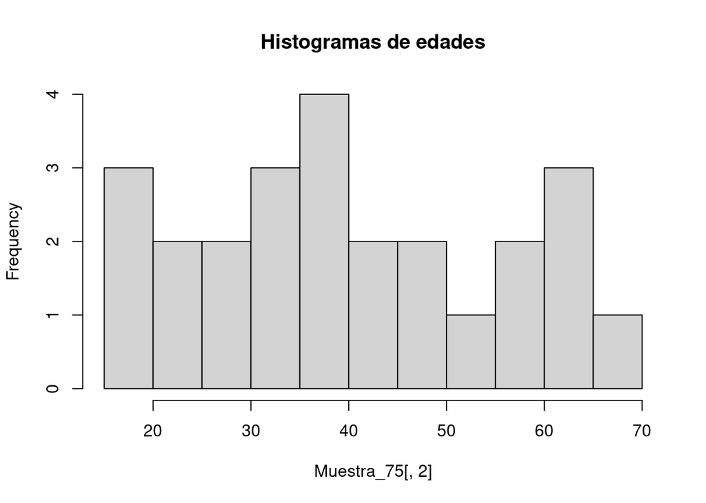

```r
hist(Muestra_75[ ,2],breaks = 10, main = "Histogramas de edades")
```

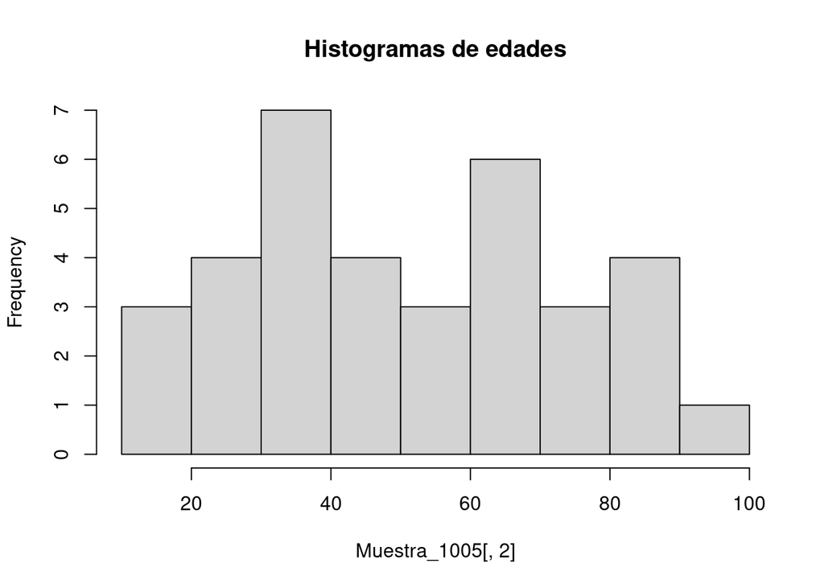

```r
hist(Muestra_1005[ ,2],breaks = 10, main = "Histogramas de edades")
```

# Gráficos de Densidad

```r
density(Muestra_75[ ,2])
```

```
##
## Call:
##  density.default(x = Muestra_75[, 2])
##
## Data: Muestra_75[, 2] (25 obs.); Bandwidth 'bw' = 7.394
##
##        x                y
##  Min.   :-5.183   Min.   :5.383e-05
##  1st Qu.:18.159   1st Qu.:2.474e-03
##  Median :41.500   Median :1.246e-02
##  Mean   :41.500   Mean   :1.070e-02
##  3rd Qu.:64.841   3rd Qu.:1.698e-02
##  Max.   :88.183   Max.   :2.186e-02
```

```r
density(Muestra_1005[ ,2])
```

```
##
## Call:
##  density.default(x = Muestra_1005[, 2])
##
## Data: Muestra_1005[, 2] (35 obs.);   Bandwidth 'bw' = 10.07
##
##        x                y
##  Min.   :-13.20   Min.   :2.409e-05
##  1st Qu.: 20.65   1st Qu.:1.550e-03
##  Median : 54.50   Median :8.491e-03
##  Mean   : 54.50   Mean   :7.377e-03
##  3rd Qu.: 88.35   3rd Qu.:1.229e-02
##  Max.   :122.20   Max.   :1.440e-02
```

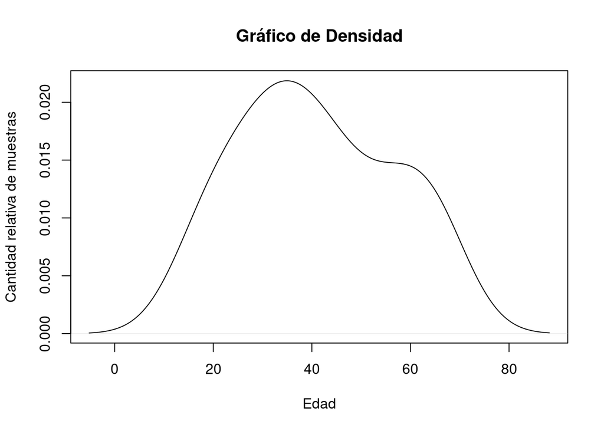

```r
plot(density(Muestra_75[ ,2]), main = "Gráfico de Densidad", ylab="Cantidad relativa de muestras",xlab="Edad")
```

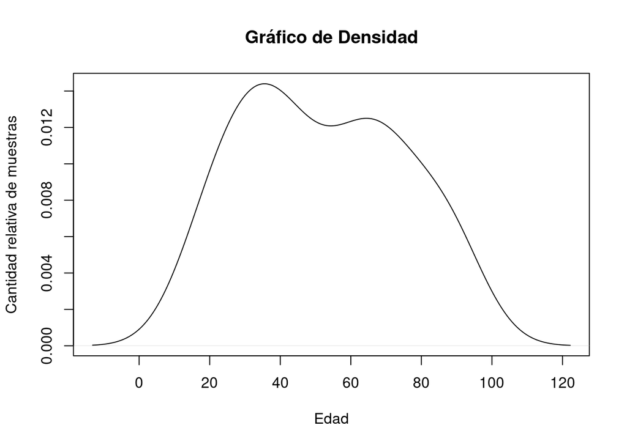

```r
plot(density(Muestra_1005[ ,2]), main = "Gráfico de Densidad", ylab="Cantidad relativa de muestras",xlab="Edad")
```

#Gráfica conjunto de Histograma y Densidad

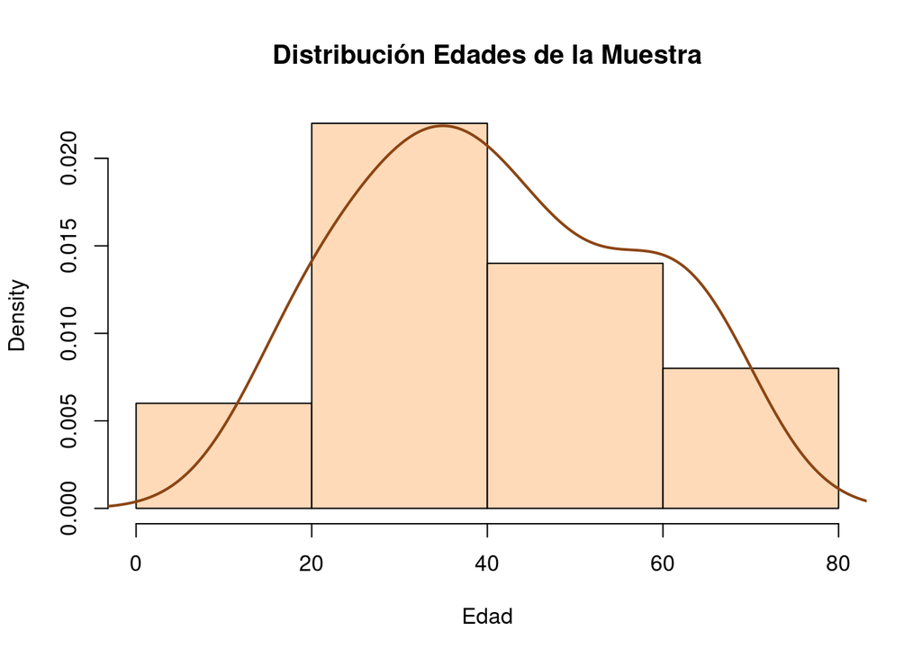

```r
hist(Muestra_75[ ,2], # histogram
    breaks = 3,
     col="peachpuff", # column color
 border="black",
 prob = TRUE, # show densities instead of frequencies
 xlab = "Edad",
 main = "Distribución Edades de la Muestra")
lines(density(Muestra_75[ ,2]), # density plot
 lwd = 2, # thickness of line
 col = "chocolate4")
```

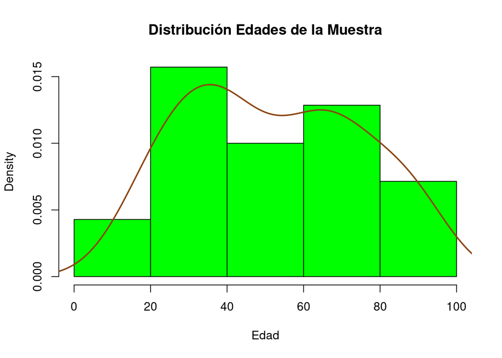

```r
hist(Muestra_1005[ ,2], # histogram
    breaks = 3,
     col="green", # column color
 border="black",
 prob = TRUE, # show densities instead of frequencies
 xlab = "Edad",
 main = "Distribución Edades de la Muestra")
lines(density(Muestra_1005[ ,2]), # density plot
 lwd = 2, # thickness of line
 col = "chocolate4")
```

## Varianza de Muestra y Población, Media, Desvio Estandar

# Varianza de la Muestra

```r
var_muestra <- var(Muestra_75 [ ,2])
var_muestra
```

```
## [1] 244.61
```

```r
var_muestra2 <- var(Muestra_1005 [ ,2])
var_muestra2
```

```
## [1] 518.7731
```

#Cantidad de Datos

```r
n <- length(Muestra_75[ ,2])
n
```

```
## [1] 25
```

```r
n2 <- length(Muestra_1005[ ,2])
n2
```

```
## [1] 35
```

```r
n_over_n_1 <- n/(n-1)
n_over_n_1
```

```
## [1] 1.041667
```

```r
n_over_n_1 <- n2/(n2-1)
n_over_n_1
```

```
## [1] 1.029412
```

# Calculo de la Media

```r
mean(Muestra_75)
```

```
## [1] 18.05333
```

```r
mean(Muestra_1005)
```

```
## [1] 23.53333
```

# Calculo del desvio standar de la duracion de las baterias

```r
sd(Muestra_75)
```

```
## [1] 19.70656
```

```r
sd(Muestra_1005)
```

```
## [1] 25.86469
```

```r
dsm <- sd({Muestra_75[ ,2]}) #valor real
dsm
```

```
## [1] 15.64001
```

```r
dsm2 <- sd({Muestra_1005[ ,2]})
dsm2
```

```
## [1] 22.77659
```

# Varianza Poblacional

```r
var_poblacion <- var(Muestra_75[ ,2]) / n
var_poblacion
```

```
## [1] 9.7844
```

```r
var_poblacion2 <- var(Muestra_1005[ ,2]) / n2
var_poblacion2
```

```
## [1] 14.82209
```

# En tanto que el desvió estándar de la población es

```r
dsp <- sqrt(var_poblacion)
dsp
```

```
## [1] 3.128003
```

```r
dsp2 <- sqrt(var_poblacion2)
dsp2
```

```
## [1] 3.849947
```

```r
sprintf("Varianza muestral =%s, Varianza poblacional = %s", var_muestra, var_poblacion )
```

```
## [1] "Varianza muestral =244.61, Varianza poblacional = 9.7844"
```

```r
sprintf("Varianza muestral 2 =%s, Varianza poblacional 2 = %s", var_muestra2, var_poblacion2 )
```

```
## [1] "Varianza muestral 2 =518.773109243697, Varianza poblacional 2 = 14.8220888355342"
```

desvío porcentual

```r
dspp_75 <- dsp/n
dspp_75
```

```
## [1] 0.1251201
```

```r
dspp_1005 <- dsp2/n2
dspp_1005
```

```
## [1] 0.1099985
```

# Graficos Resumen de Cajas y Bigotes

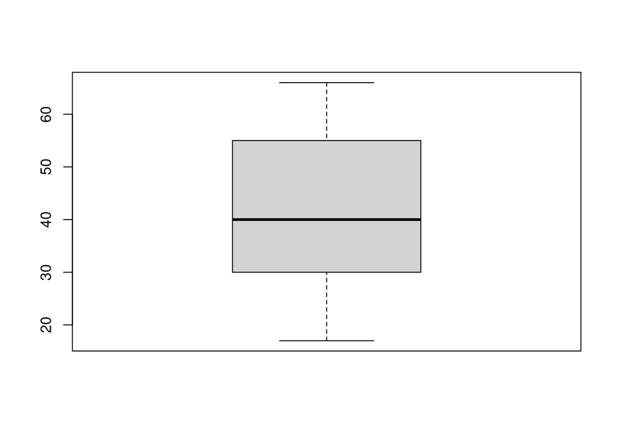

```r
boxplot(Muestra_75[ ,2])
```

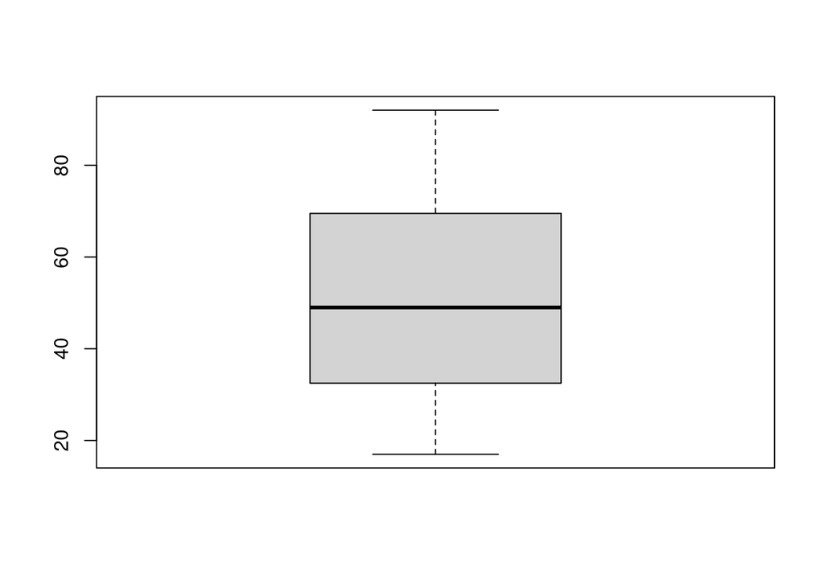

```r
boxplot(Muestra_1005[ ,2])
```

Analizando los graficos, podemos decir que las Baterias de SIEMENS 1005 muestra una mejor duracion media respecto a las baterias de VARTA 75.

```r
summary(Muestra_75[ ,2])
```

```
##    Min. 1st Qu.  Median    Mean 3rd Qu.    Max.
##   17.00   30.00   40.00   40.88   55.00   66.00
```

```r
summary(Muestra_1005[ ,2])
```

```
##    Min. 1st Qu.  Median    Mean 3rd Qu.    Max.
##   17.00   32.50   49.00   52.14   69.50   92.00
```

## Gráfico de Comparación

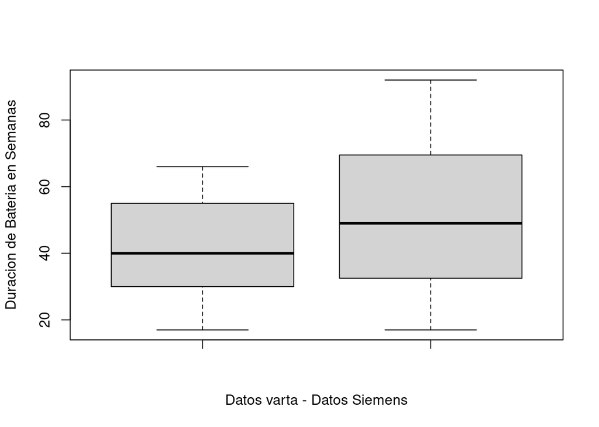

```r
boxplot(Muestra_75[ ,2],Muestra_1005[ ,2],xlab="Datos varta - Datos Siemens",ylab="Duracion de Bateria en Semanas")
```

## PRUEBA STUDENT

```r
t.test(Muestra_75,Muestra_1005)
```

```
##
##  Welch Two Sample t-test
##
## data:  Muestra_75 and Muestra_1005
## t = -1.6125, df = 177.22, p-value = 0.1086
## alternative hypothesis: true difference in means is not equal to 0
## 95 percent confidence interval:
##  -12.186572   1.226572
## sample estimates:
## mean of x mean of y
##  18.05333  23.53333
```